# Praca domowa 2

# Jan Kwiecień

## **1. Wstęp**

W ramach pracy domowej numer dwa mieliśmy za zadanie znalezienie wykresu dostępnego w prasie, telewizji bądź w internecie w celu weryfikacji jego poprawności i prawidłowym skonstruowaniu go ponownie.

Ja do tego zadania wybrałem wykres zaprezentowany w Wiadomościach na kanale TVP1 dnia 03.03.2023. Przedstawia on przewidywany (przez pewną grupę badawczą) wynik nadchodzących wyborów parlamentarnych. Przyjrzyjmy mu się bliżej.

[figure not shown]

Wykres TVP Wiadomości 03.03.2023 19:30, https://vod.tvp.pl/informacje-i-publicystyka,205/wiadomosci-odcinki,2737266

## **2. Analiza wykresu**

Ankietowani mieli do wyboru trzy opcje: dwie partie oraz odpowiedź “inne ugrupowanie”. Widzimy, że respondenci wybrali w większości partię Prawo i Sprawiedliwość, Koalicja Obywatelska uplasowała się na drugiej pozycji. Co jest nie tak w tym wykresie? Każda z odpowiedzi zaprezentowana jest na podwyższeniu, co daje wrażenie niepoprawności wyników (8 % pozostałych odpowiedzi jest mniej więcej na wysokości 15 Koalicji Obywatelskiej). Ponadto zastosowano wykresy słupokowe trójwymiarowe. W rezultacie wyniki wysokie wydają się być jeszcze wyższe.

## **3. Rozwiązanie**

W moim przypadku dokonałem dwóch wyraźnych zmian. Zamieniłem wykres 3d na słupkowy 2d oraz podpisałem odpowiednie słupki pod osią OX. Prezentuje się on następująco.

```
library(ggplot2)

first_column <- c("PiS", "KO", "inne")
second_column <- c(52L, 40L, 8L)

df <- data.frame(first_column, second_column)
colnames(df) <-  c("Partie", "Głosy")

ggplot(df, aes(x = reorder(Partie, -Głosy), y = Głosy, fill = Partie)) +
  scale_fill_manual(values = c("#082E79", "#00BFFF", "#87CEFA")) +
  geom_col(width = 0.6, colour = "black") +
  labs(title = "Kto wygra najbliższe wybory jesienią tego roku i będzie rządził w Polsce",
           x = "Partie",
           y = "Głosy")  +
  theme(plot.title = element_text(hjust = 0.45)) +
  theme(panel.background = element_rect(fill = 'grey', colour = 'black'))
```

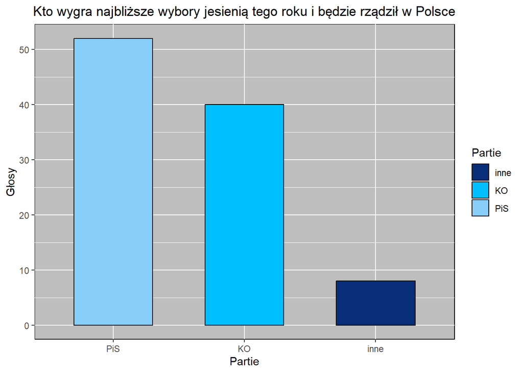

## **4. Podsumowanie**

Zaprezentowany wykres zawierał dwa podstawowe błędy: został zkonstruowany w 3d oraz nie przedstawiał wyników od poziomu 0. Zaproponowane zmiany eliminują je, wprowadzając więcej przejrzystości w odczytywaniu danych.